신록예찬's 블로그

# (연구) HST example 1 (8), 결과좋음

완성

Aug 5, 2021 • 신록예찬 • 5 min read

기하학적 딥러닝 논문연구

- Import
- Data
- HST
- Distance
- Decomposition of Distance
- 시각화를 위해서 R로 자료를 옮김
- R을 활용한 시각화 (1): 원래자료
- R을 활용한 시각화 (2): Weight matrix 와 Eigen plot
- R을 활용한 시각화 (3): Decomposition

### Import

```python
import heavysnow as hs
import numpy as np
import pandas as pd
import matplotlib.pyplot as plt
import rpy2
%load_ext rpy2.ipython
%run pybase
```

### Data

```python
f=np.array([-1,-1,-1,1,-1,-1,-1,1,1,1,-1,1,1,1])*1.0
n=len(f)
V=list(range(n))
W=np.zeros([n,n])
for i in range(n):
    for j in range(n):
        if abs(i-j)==1: W[i,j]=1
W[0,0]=0.5
W[n-1,n-1]=0.5
```

```python
gs=hs.GraphSignal(V,W,f)
```

```python
gs.initdist=np.array([1/n]*n)
```

### HST

```python
hst=hs.HeavySnowTransform(gs)
hst.snow(tau=80000,b=0.03)
```

```
HST (tau= 80000, b=0.03)
80000/80000
HST completed and all history is recorded.
```

### Distance

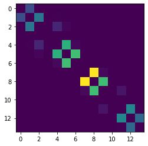

```python
plt.imshow(hst.snowweight)
```

### Decomposition of Distance

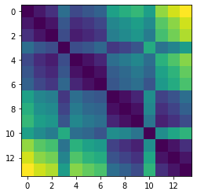

```python
plt.imshow(hst.snowdistance)
```

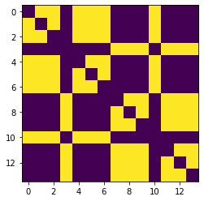

```python
plt.imshow(np.exp(-hst.snowdistance1/(hst.tau*hst.b**2))-np.eye(hst.n))
```

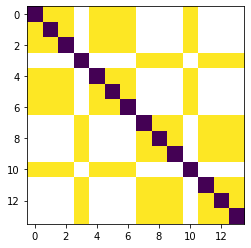

```python
plt.imshow(np.exp(-hst.snowdistance2/(hst.tau*hst.b**2))-np.eye(hst.n))
```

[figure not shown]

```python
plt.imshow(np.exp(-hst.snowdistance3/(hst.tau*hst.b**2))-np.eye(hst.n))
```

```python
hst.snowdistance3
```

```
array([[0.00000000e+00, 2.70531900e+02, 5.96393100e+02, 3.10670539e+05,
        9.25812000e+02, 1.12955580e+03, 1.32894360e+03, 3.09264792e+05,
        3.08101043e+05, 3.12987462e+05, 2.38146570e+03, 3.15581896e+05,
        3.14750113e+05, 3.25038582e+05],
       [2.70531900e+02, 0.00000000e+00, 2.34820800e+02, 3.19297476e+05,
        5.30954100e+02, 6.80012100e+02, 9.02438100e+02, 3.17799452e+05,
        3.16601501e+05, 3.21545686e+05, 2.02199400e+03, 3.24165195e+05,
        3.23310353e+05, 3.33732428e+05],
       [5.96393100e+02, 2.34820800e+02, 0.00000000e+00, 3.16647116e+05,
        3.31640100e+02, 4.85815500e+02, 6.89314500e+02, 3.15179563e+05,
        3.13985942e+05, 3.18907028e+05, 1.76110560e+03, 3.21519218e+05,
        3.20668946e+05, 3.31045977e+05],
       [3.10670539e+05, 3.19297476e+05, 3.16647116e+05, 0.00000000e+00,
        3.18039154e+05, 3.22422367e+05, 3.19862052e+05, 6.87177900e+02,
        8.61469200e+02, 1.10288250e+03, 3.13225241e+05, 1.59449130e+03,
        1.89286560e+03, 2.32166520e+03],
       [9.25812000e+02, 5.30954100e+02, 3.31640100e+02, 3.18039154e+05,
        0.00000000e+00, 1.99209600e+02, 4.50489600e+02, 3.16295063e+05,
        3.15108061e+05, 3.20027489e+05, 1.51503750e+03, 3.22643580e+05,
        3.21787906e+05, 3.32182607e+05],
       [1.12955580e+03, 6.80012100e+02, 4.85815500e+02, 3.22422367e+05,
        1.99209600e+02, 0.00000000e+00, 1.93383000e+02, 3.20275682e+05,
        3.19065413e+05, 3.24027851e+05, 1.38610890e+03, 3.26618769e+05,
        3.25730651e+05, 3.36186270e+05],
       [1.32894360e+03, 9.02438100e+02, 6.89314500e+02, 3.19862052e+05,
        4.50489600e+02, 1.93383000e+02, 0.00000000e+00, 3.17317010e+05,
        3.16139546e+05, 3.21046120e+05, 1.11086550e+03, 3.23641396e+05,
        3.22747479e+05, 3.33154161e+05],
       [3.09264792e+05, 3.17799452e+05, 3.15179563e+05, 6.87177900e+02,
        3.16295063e+05, 3.20275682e+05, 3.17317010e+05, 0.00000000e+00,
        1.67195700e+02, 4.31233200e+02, 3.10429692e+05, 8.22825000e+02,
        1.07751870e+03, 1.52637030e+03],
       [3.08101043e+05, 3.16601501e+05, 3.13985942e+05, 8.61469200e+02,
        3.15108061e+05, 3.19065413e+05, 3.16139546e+05, 1.67195700e+02,
        0.00000000e+00, 1.93625100e+02, 3.08883988e+05, 5.89936500e+02,
        8.42025600e+02, 1.29378780e+03],
       [3.12987462e+05, 3.21545686e+05, 3.18907028e+05, 1.10288250e+03,
        3.20027489e+05, 3.24027851e+05, 3.21046120e+05, 4.31233200e+02,
        1.93625100e+02, 0.00000000e+00, 3.13296156e+05, 3.79155600e+02,
        6.13280700e+02, 9.86177700e+02],
       [2.38146570e+03, 2.02199400e+03, 1.76110560e+03, 3.13225241e+05,
        1.51503750e+03, 1.38610890e+03, 1.11086550e+03, 3.10429692e+05,
        3.08883988e+05, 3.13296156e+05, 0.00000000e+00, 3.15615132e+05,
        3.14808366e+05, 3.25067131e+05],
       [3.15581896e+05, 3.24165195e+05, 3.21519218e+05, 1.59449130e+03,
        3.22643580e+05, 3.26618769e+05, 3.23641396e+05, 8.22825000e+02,
        5.89936500e+02, 3.79155600e+02, 3.15615132e+05, 0.00000000e+00,
        2.23425900e+02, 5.65998300e+02],
       [3.14750113e+05, 3.23310353e+05, 3.20668946e+05, 1.89286560e+03,
        3.21787906e+05, 3.25730651e+05, 3.22747479e+05, 1.07751870e+03,
        8.42025600e+02, 6.13280700e+02, 3.14808366e+05, 2.23425900e+02,
        0.00000000e+00, 2.45154600e+02],
       [3.25038582e+05, 3.33732428e+05, 3.31045977e+05, 2.32166520e+03,
        3.32182607e+05, 3.36186270e+05, 3.33154161e+05, 1.52637030e+03,
        1.29378780e+03, 9.86177700e+02, 3.25067131e+05, 5.65998300e+02,
        2.45154600e+02, 0.00000000e+00]])
```

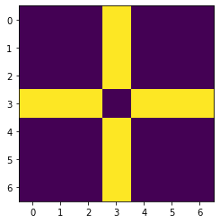

```python
plt.imshow(hst.snowdistance1[0:7,0:7])
```

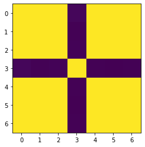

```python
plt.imshow(hst.snowdistance2[0:7,0:7])
```

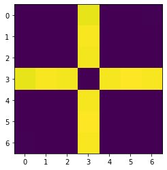

```python
plt.imshow(hst.snowdistance3[0:7,0:7])
```

```python
hst.snowdistance3[0:7,0:7]+hst.snowdistance2[0:7,0:7]
```

```
array([[ 0.00000000e+00,  2.70531900e+02,  5.96393100e+02,
        -3.18479621e+05,  9.25812000e+02,  1.12955580e+03,
         1.32894360e+03],
       [ 2.70531900e+02,  0.00000000e+00,  2.34820800e+02,
        -3.18857124e+05,  5.30954100e+02,  6.80012100e+02,
         9.02438100e+02],
       [ 5.96393100e+02,  2.34820800e+02,  0.00000000e+00,
        -3.19019404e+05,  3.31640100e+02,  4.85815500e+02,
         6.89314500e+02],
       [-3.18479621e+05, -3.18857124e+05, -3.19019404e+05,
         0.00000000e+00, -3.19014686e+05, -3.18883313e+05,
        -3.18606828e+05],
       [ 9.25812000e+02,  5.30954100e+02,  3.31640100e+02,
        -3.19014686e+05,  0.00000000e+00,  1.99209600e+02,
         4.50489600e+02],
       [ 1.12955580e+03,  6.80012100e+02,  4.85815500e+02,
        -3.18883313e+05,  1.99209600e+02,  0.00000000e+00,
         1.93383000e+02],
       [ 1.32894360e+03,  9.02438100e+02,  6.89314500e+02,
        -3.18606828e+05,  4.50489600e+02,  1.93383000e+02,
         0.00000000e+00]])
```

### 시각화를 위해서 R로 자료를 옮김

```python
maxtau=hst.tau
W_Graph=hst.graphweight
W_Euclid=hst.euclidweight
W_HST=hst.snowweight
V=np.array(hst.V)
f=hst.f
n=hst.n
%R -i maxtau,W_Graph,W_Euclid,W_HST,V,f,n
```

### R을 활용한 시각화 (1): 원래자료

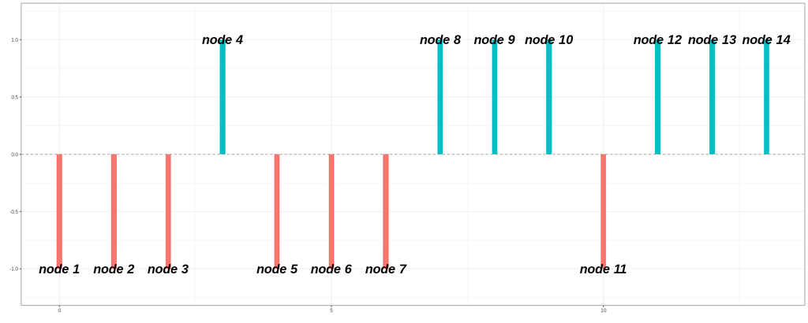

```python
%%R -w 2000 -h 800 -r 100
library(tidyverse)
library(latex2exp)
library(gridExtra)
source('rbase.R')
Vtext=str_c('node ',V+1)
fig0<-ggplot(data=tibble(V=V,f=f,Vtext=Vtext),aes(x=V,y=f,label=Vtext))+
geom_col(aes(fill=(f>0)),width=0.1)+geom_hline(aes(yintercept=0),col="gray60",lty=2)+
geom_text(fontface = 4,size=8)+
xlab("")+ylab("")+guides(fill=FALSE)+theme(plot.title=element_text(face="bold.italic"))+theme_bw()+
theme(strip.text.x = element_text(size = 20, color = "black", face = "bold.italic"))+
theme(strip.text.y = element_text(size = 15, color = "black", face = "bold.italic"))+
ylim(-1.2,1.2)+
theme(plot.title=element_text(face="bold.italic"))
#ggsave(plot=p0,"./fig/2021-0217_fig0.pdf",width=20,height=6)
fig0
```

### R을 활용한 시각화 (2): Weight matrix 와 Eigen plot

`-` `ggplot`에서 `geom_tile`을 사용하기 위해서 매트릭스 형태인 `W_Graph`, `W_Euclid`, `W_HST`를 길게 펼친다. 결과를 각각 `W_Graph_long`, `W_Euclid_long`, `W_HST_long`에 저장한다.

```python
%%R
grid<-expand.grid(x=1:n,y=1:n)
W_Graph_long<-as_tibble(cbind(grid,as.vector(W_Graph)));names(W_Graph_long)<-c("x","y","W")
W_Euclid_long<-as_tibble(cbind(grid,as.vector(W_Euclid)));names(W_Euclid_long)<-c("x","y","W")
W_HST_long<-as_tibble(cbind(grid,as.vector(W_HST)));names(W_HST_long)<-c("x","y","W")
```

`-` 그래프퓨리에 변환: $(\bf{f},\bf{W})$에 그래프 퓨리에 변환을 수행함.

```python
%%R
source('heavysnow.R')
gfftrslt_Euclid<-gfft(f,W_Euclid)
gfftrslt_Graph<-gfft(f,W_Graph)
gfftrslt_HST<-gfft(f,W_HST)
```

`-` 그래프 퓨리에 변환의 결과 고유치, 고유벡터, $\bf{\bar{f}}$가 반환됨.

```python
%%R
head(gfftrslt_HST)
```

```
$λ
 [1] 1.975146e+00 1.961984e+00 1.940866e+00 1.894293e+00 1.098055e+00
 [6] 1.063357e+00 9.741852e-01 9.379245e-01 1.077364e-01 4.629040e-02
[11] 1.548058e-04 7.085135e-06 1.248744e-15 3.855869e-21

$Ψ
               [,1]          [,2]          [,3]          [,4]          [,5]
 [1,]  3.424833e-06 -2.614136e-01  4.810724e-06  3.830408e-01 -4.981610e-01
 [2,] -5.548447e-06  4.176481e-01 -7.512999e-06 -5.678859e-01  7.504753e-02
 [3,]  4.919835e-06 -3.577764e-01  6.071014e-06  3.970836e-01  4.374990e-01
 [4,] -3.057231e-09  1.241746e-11  3.562700e-09 -1.063670e-10 -6.450956e-12
 [5,] -7.013773e-06  4.077801e-01 -3.954134e-06  2.366151e-01 -5.565053e-01
 [6,]  9.992210e-06 -5.531925e-01  4.557299e-06 -4.452296e-01 -4.827850e-02
 [7,] -7.747639e-06  3.961344e-01 -2.516988e-06  3.448099e-01  4.927160e-01
 [8,]  3.633138e-01  7.611655e-07 -4.146922e-01  2.465962e-06 -7.299973e-06
```

[output cut: 41 more lines]

`-` 시각화코드

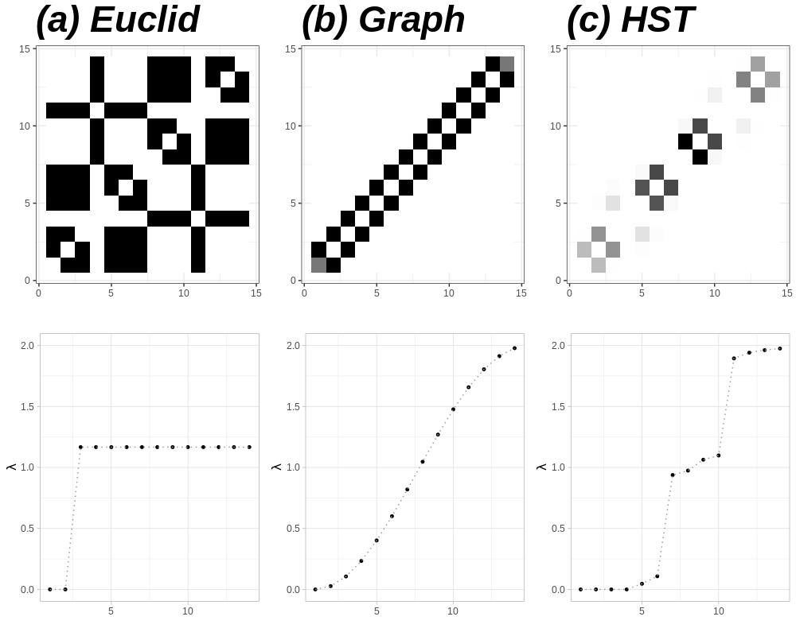

```python
%%R -w 1000 -h 800 -r 100
library(gridExtra)

fig1_1<-ggplot()+geom_tile(data=W_Euclid_long,aes(x=x,y=y,fill=W))+theme_bw()+xlab("")+ylab("")+
theme(strip.text.x = element_text(size = 20, color = "black", face = "bold.italic"))+
theme(strip.text.y = element_text(size = 20, color = "black", face = "bold.italic"))+
scale_fill_gradient2(low="white",high="black")+
labs(fill=TeX('$W$'))+
theme(legend.position="none")+theme(legend.key=element_blank())+
ggtitle("(a) Euclid")+theme(plot.title=element_text(face="bold.italic",size=rel(3)))

fig1_2<-ggplot()+geom_tile(data=W_Graph_long,aes(x=x,y=y,fill=W))+theme_bw()+xlab("")+ylab("")+
theme(strip.text.x = element_text(size = 20, color = "black", face = "bold.italic"))+
theme(strip.text.y = element_text(size = 20, color = "black", face = "bold.italic"))+
scale_fill_gradient2(low="white",high="black")+
labs(fill=TeX('$\\hat{W}$'))+
theme(legend.position="none")+theme(legend.key=element_blank())+
ggtitle("(b) Graph")+theme(plot.title=element_text(face="bold.italic",size=rel(3)))

fig1_3<-ggplot()+geom_tile(data=W_HST_long,aes(x=x,y=y,fill=W))+theme_bw()+xlab("")+ylab("")+
theme(strip.text.x = element_text(size = 20, color = "black", face = "bold.italic"))+
theme(strip.text.y = element_text(size = 20, color = "black", face = "bold.italic"))+
scale_fill_gradient2(low="white",high="black")+
labs(fill=TeX('$\\hat{W}(\\tau)$'))+
theme(legend.position="none")+theme(legend.key=element_blank())+
ggtitle("(c) HST")+theme(plot.title=element_text(face="bold.italic",size=rel(3)))

fig1_4<-eigenplot(gfftrslt_Euclid)+ylim(0,2)+theme_light()
fig1_5<-eigenplot(gfftrslt_Graph)+ylim(0,2)+theme_light()
fig1_6<-eigenplot(gfftrslt_HST)+ylim(0,2)+theme_light()
fig1=grid.arrange(fig1_1,fig1_2,fig1_3,fig1_4,fig1_5,fig1_6,ncol=3,nrow=2)
fig1
ggsave(plot=fig1,"asdf2.pdf",width=15,height=10)
```

### R을 활용한 시각화 (3): Decomposition

`-` 디콤포지션을 수행하고 결과를 저장: $(\bf{f},\bf{W})$에 decomposition을 수행하고 그 결과를 각각 `decomprslt_Euclid`, `decomprslt_Graph`, `decomprslt_HST`에 저장한다.

```python
%%R
decomprslt_Euclid<-decompose(f,W_Euclid,V=1:n) # 0, 35000, 60000, 80000
decomprslt_Graph<-decompose(f,W_Graph,V=1:n) # 0, 35000, 60000, 80000
decomprslt_HST<-decompose(f,W_HST,V=1:n) # 0, 35000, 60000, 80000
```

`-` 디콤포지션 결과는 아래와 같은 형태임

```python
%%R
head(decomprslt_Euclid)
```

```
# A tibble: 6 x 5
      V Vindex eigenvectorindex      fhat eigenvalue
  <int>  <int>            <dbl>     <dbl>      <dbl>
1     1      1                1  8.02e-18   4.04e-18
2     2      2                1  2.04e-16   4.04e-18
3     3      3                1 -1.94e-16   4.04e-18
4     4      4                1  1.00e+ 0   4.04e-18
5     5      5                1 -3.67e-17   4.04e-18
6     6      6                1  1.20e-16   4.04e-18
```

```python
%%R
decomprslt_Euclid$method="Euclid"
decomprslt_Graph$method="Graph"
decomprslt_HST$method="HST"
decomprslt<-rbind(decomprslt_Euclid,decomprslt_Graph,decomprslt_HST)
```

`-` 디콤포지션결과를 시각화한다. `geom_col`과 `facet_grid`를 이용.

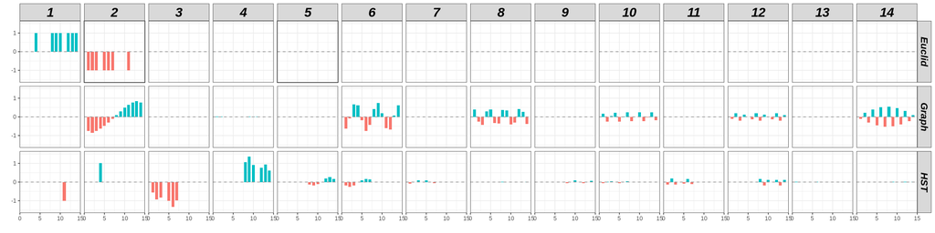

```python
%%R -w 2000 -h 500 -r 100
fig2<-ggplot(data=decomprslt,aes(x=V,y=fhat))+
geom_col(aes(fill=fhat>0),width=0.7)+facet_grid(method~eigenvectorindex)+geom_hline(aes(yintercept=0),col="gray60",lty=2)+
xlab("")+ylab("")+guides(fill=FALSE)+theme(plot.title=element_text(face="bold.italic"))+theme_bw()+
theme(strip.text.x = element_text(size = 20, color = "black", face = "bold.italic"))+
theme(strip.text.y = element_text(size = 15, color = "black", face = "bold.italic"))+
ylim(-1.5,1.5)+
theme(plot.title=element_text(face="bold.italic"))
fig2
#ggsave(plot=fig2,"asdf.pdf",width=20,height=6)
```